# Katoh lite

Owen McGrattan

2/15/2020

## Katoh

### Read in data and libraries

```r
# import libraries
library(readr)
library(dplyr)
```

```r
library(ggplot2)
library(caret)
library(randomForest)
library(UBL)
# read in 2006-2019 mlb thru age 28 data
mlb <- read_csv("./katoh_data/mlb_thru_28.csv")


# read in 2006-2019 minor league data
a_minor <- read_csv("./katoh_data/2007-19_A_minor_advanced.csv")
low_a <- read_csv("./katoh_data/2007-19_Alow_minor_advanced.csv")
high_minor <- read_csv("./katoh_data/2007-19_high_minor_advanced.csv")

a_minor_batted <- read_csv("./katoh_data/2007-19_A_minor_batted.csv")
low_a_batted <- read_csv("./katoh_data/2007-19_Alow_minor_batted.csv")
high_minor_batted <- read_csv("./katoh_data/2007-19_high_minor_batted.csv")

# read in rookie data
rookies <- read_csv("./katoh_data/rookies.csv")

# read in major league positional data
defense <- read_csv("./katoh_data/defense.csv")
```

```r
# before we merge, we want to take out overlap columns in our batted sets
a_minor_batted <- a_minor_batted %>% select(-c(Age, PA, BABIP, PlayerId, Balls, Strikes, Pitches))
low_a_batted <- low_a_batted %>% select(-c(Age, PA, BABIP, PlayerId, Balls, Strikes, Pitches))
high_minor_batted <- high_minor_batted %>% select(-c(Age, PA, BABIP, PlayerId, Balls, Strikes, Pitches))

#a_minor_batted <- a_minor_batted %>% select(Season, Name, Team, `SwStr%`)
#low_a_batted <- low_a_batted %>% select(Season, Name, Team, `SwStr%`)
#high_minor_batted <- high_minor_batted %>% select(Season, Name, Team, `SwStr%`)
# merge data sets together
# left merge standard and batted ball first
a_minor <- merge(a_minor, a_minor_batted, by = c("Season", "Name", "Team"))
low_a <- merge(low_a, low_a_batted, by = c("Season", "Name", "Team"))
high_minor <- merge(high_minor, high_minor_batted, by = c("Season", "Name", "Team"))

# take out a- and below ( for now, this is highly variable )
minors <- rbind(a_minor,  high_minor)

rm(a_minor_batted, low_a_batted, high_minor_batted, a_minor, low_a, high_minor)
```

attach defense to mlb player set. first

```r
# for each unique player, filter defense dataset, group by pos, grab pos with most innings played
temp <- data.frame(Name = NA,
                   playerid = unique(defense$playerid),
                   pos = NA)

for (i in 1:nrow(temp)) {
  d <- filter(defense, playerid == temp$playerid[i])
  group <- d %>% group_by(Pos, Name) %>% summarise(inn = sum(Inn), .groups = 'drop')
  temp$pos[i] <- group$Pos[which.max(group$inn)]
  temp$Name[i] <- group$Name[1]
}

# merge with dat
mlb <- merge(mlb, temp, by = c("Name", "playerid"))

# get rid of any pitchers
mlb <- mlb %>% filter(pos != "P")
```

```r
# we want to add a war/162 variable instead because overall war is not suitable rn
mlb$war_162 <- (mlb$WAR / mlb$G) * 162

# only include those with at least 600 PA
mlb <- filter(mlb, PA >= 600)
```

```r
# merge minor with major dataset
# first hold major league set with war_162 and wrc+
a <- mlb %>% select(Name, `wRC+`, WAR, PA, war_162)
a <- a %>% rename(mlb_wrc_plus = `wRC+`,
                  mlb_pa = PA)

dat <- left_join(minors, a, by = "Name")


# filter out any age 29 or greater seasons in the minors
dat <- dat %>% filter(Age < 29, Season < 2016)
```

```r
# add war/162 lvl
dat$war_lvl_162 <- NA
for (i in 1:nrow(dat)) {
  if (is.na(dat$WAR[i])) {
    dat$war_lvl_162[i] <- '0'
  } else if (dat$war_162[i] >= 6.0) {
    dat$war_lvl_162[i] <- '7'
  } else if (dat$war_162[i] >= 5.0) {
    dat$war_lvl_162[i] <- '6'
  } else if (dat$war_162[i] >= 4.0) {
    dat$war_lvl_162[i] <- '5'
  } else if (dat$war_162[i] >= 3.0) {
    dat$war_lvl_162[i] <- '4'
  } else if (dat$war_162[i] >= 2.0) {
    dat$war_lvl_162[i] <- '3'
  } else if (dat$war_162[i] >= 1.0) {
    dat$war_lvl_162[i] <- '2'
  } else {
    dat$war_lvl_162[i] <- '1'
  }
}
```

Just to see the class levels now, let’s see a distribution

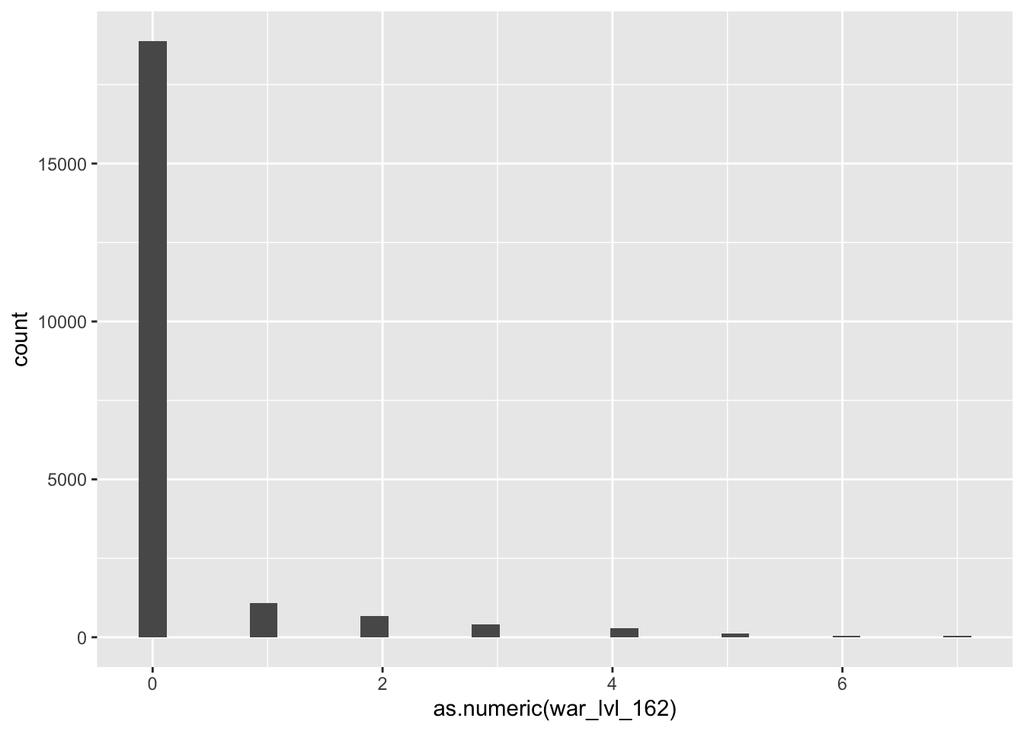

```r
ggplot(dat) + geom_histogram(aes(as.numeric(war_lvl_162)))
```

While it does not represent the true population, for the purposes of this rough exercise we do not want the class imbalance to throw off the classification. And since I plan on applying this list to a list of already fairly highly ranked prospects, I’m not too concerned about discounting the probabilities that they do not make the majors. Even still, I will expect the model will still cast a good amount of doubt on many MLB chances and thus drive down the end war/162 projection.

We have cleaned our set for the most part but we still need to separate team names as well as label affiliate as it’s own factor variable

```r
# strsplit for each league
dat$level <- NA
for (i in 1:nrow(dat)) {
  txt <- strsplit(dat$Team[i], " ")[[1]]
  dat$level[i] <- txt[length(txt)]
}


# turn all our character vals into factors
dat =dat %>% mutate_if(is.character, as.factor)
```

Now we can start modeling.

```r
# try no R ball
#no_r <- dat %>% filter(mlb_pa > 1000)

# generate test train splits 85/15
uniq_names <- unique(dat$Name)
smp_size <- floor(0.85 * length(uniq_names))
set.seed(123)

train_ind <- sample(seq_len(length(uniq_names)), size = smp_size)
train_names <- uniq_names[train_ind]
test_names <- uniq_names[-train_ind]


train <- dat %>% filter(Name %in% train_names)
test <- dat %>% filter(Name %in% test_names)



train <- select(train, -c(Name, Season, Team, PlayerId, mlb_wrc_plus, WAR, mlb_pa,  wRC, wSB, wRAA, war_162))

# before we go further, we want to oversample our training values to combat some of the class imbalance in our set
train <- SmoteClassif(war_lvl_162 ~ ., dat = train, C.perc = 'balance', k = 8, dist = 'HEOM')
x_train <- select(train, -war_lvl_162)
y_train <- train$war_lvl_162

x_test <- select(test, -c(Name, Season, Team, PlayerId, mlb_wrc_plus, WAR, mlb_pa, wRC, wSB, wRAA, war_162, war_lvl_162))
y_test <- test$war_lvl_162
```

We’ve introduced some oversampling in our training set to try and counter some of the heavy class imbalance. The strategy here was to oversample all minority classes to be equal our 0 war level. More can be done with this later but for now it should serve as an improvement over the previous iteration of slightly scaling down the 0 and 1 war level players.

xgboost model, with some more class balance

```r
library(xgboost)
# transform level into numeric variable
x_train$level <- as.integer(x_train$level)
x_test$level <- as.integer(x_test$level)

train$war_lvl_162 <- as.numeric(levels(train$war_lvl_162))[train$war_lvl_162]
test$war_lvl_162 <- as.numeric(levels(test$war_lvl_162))[test$war_lvl_162]

xgb.train = xgb.DMatrix(data=as.matrix(x_train),label= train$war_lvl_162)
xgb.test = xgb.DMatrix(data=as.matrix(x_test),label= test$war_lvl_162)
```

```r
# Define the parameters for multinomial classification
num_class = length(unique(train$war_lvl_162))
params = list(
  booster="gbtree",
  eta=0.03,
  max_depth=5,
  gamma=10,
  subsample=0.75,
  colsample_bytree=1,
  objective="multi:softprob",
  eval_metric="mlogloss",
  max_delta_step = 1,
  num_class=num_class
)
```

```r
# Train the XGBoost classifer
xgb.fit=xgb.train(
  params=params,
  data=xgb.train,
  nrounds=500,
  nthreads=1,
  early_stopping_rounds=5,
  watchlist=list(val1=xgb.train,val2=xgb.test),
  print_every_n = 10
)
```

[output not shown]

```r
xgb.pred = predict(xgb.fit,xgb.test,reshape=T)
xgb.pred = as.data.frame(xgb.pred)
colnames(xgb.pred) = levels(as.factor(train$war_lvl_162))


# Use the predicted label with the highest probability
xgb.pred$prediction = apply(xgb.pred,1,function(x) colnames(xgb.pred)[which.max(x)])
xgb.pred$label = test$war_lvl_162

# Calculate the final accuracy
result = sum(xgb.pred$prediction==xgb.pred$label)/nrow(xgb.pred)
print(paste("Final Accuracy =",sprintf("%1.2f%%", 100*result)))
```

```
## [1] "Final Accuracy = 68.99%"
```

Our overall accuracy will still be low as it can be awfully difficult to project out for young hitters, but our change in oversampling has bumped our accuracy. This is still not particularly robust as we should do a better job of parameter tuning for the model but a nice jump.

```r
# multiclass decision matrix
table(xgb.pred$label, xgb.pred$prediction)
```

```
##
##        0    1    2    3    4    5    6    7
##   0 2088  277   90   94   83   44   20   29
##   1   39   35   26   12   12   10    2    3
##   2   31   29   19   15   17    7    7   13
##   3   26   12    7   12    7    5    3    3
##   4    5    1    6    4    3    3    2    4
##   5    0    5    0    5    1    2    1    1
##   6    3    0    2    0    0    2    1    3
```

I’m celebrating that small jump in accuracy partly due to the fact that we have a confusion matrix that still has some variance on both sides of the diagonal. We could reach a really high accuracy by simply guessing every player to be a 0 war player but that wouldn’t be useful for anyone.  
###### save model

```r
saveRDS(xgb.fit, "xgb.rds")
```